# Day 2 Part 3: Application to S&P 500 Stock Portfolio

Zero to Hero Bootcamp - Time Series Econometrics in R

Author

Dr Christian Engels

Last updated

November 22, 2024

## Introduction

In this session, we will apply time series econometric techniques to an S&P 500 stock portfolio. The objectives are:

- Download and preprocess S&P 500 stock data.
- Construct a minimum variance portfolio.
- Fit a GARCH model to the portfolio returns.
- Evaluate the model and perform rolling forecasts.
- Assess Value at Risk (VaR) using the fitted model.

## Loading Required Libraries

We begin by loading the necessary R packages for data manipulation, time series analysis, portfolio optimization, and modeling.

```r
library(tidyverse)         # Data manipulation and visualization
library(tidyfinance)       # Financial data tools
library(tsibble)           # Time series data manipulation
library(feasts)            # Time series features
library(rugarch)           # Univariate GARCH models
library(PortfolioAnalytics) # Portfolio optimization
library(xts)               # Extensible time series
```

## Data Acquisition

### Downloading S&P 500 Constituents and Prices

We download the S&P 500 constituents and their historical adjusted closing prices. If the data already exists locally, we read it from the CSV file to save time.

```r
if (!file.exists("sp500_download.csv")) {

  # Download S&P 500 constituents
  constituents <- download_data("constituents", index = "S&P 500")

  # Download historical stock prices for all constituents
  sp500_download <-
    download_data(
      "stock_prices",
      symbols = constituents %>% pull(symbol),
      start_date = "2014-11-18",
      end_date = "2024-11-18"
    )

  # Save the data to CSV for future use
  sp500_download %>% write_csv("sp500_download.csv")
} else {
  # Read the data from CSV if it exists
  sp500_download <- read_csv("sp500_download.csv")
}
```

## Data Preparation

### Calculating Daily Returns

We calculate the daily returns for each stock in the S&P 500 index. We also ensure that we only keep stocks with complete data over the entire period.

```r
sp500_returns <-
  sp500_download %>%
  select(symbol, date, adjusted_close) %>%
  group_by(symbol) %>%
  arrange(date) %>% # Ensure data is sorted by date
  mutate(
    return = adjusted_close / lag(adjusted_close) - 1
  ) %>%
  ungroup() %>%
  drop_na(return) %>% # Remove NAs resulting from lag
  group_by(symbol) %>%
  mutate(n_days = n()) %>%
  ungroup() %>%
  filter(n_days == max(n_days)) %>% # Keep symbols with full data
  select(symbol, date, return)
```

### Transforming Data to Wide Format

We pivot the data to a wide format where each column represents the returns of a stock, and each row represents a date.

```r
sp500_wide <-
  sp500_returns %>%
  pivot_wider(
    id_cols = date,
    values_from = return,
    names_from = symbol
  ) %>%
  mutate(date = as_date(date))
sp500_wide
```

```
# A tibble: 2,515 × 469
   date            NVDA      AAPL     MSFT      AMZN     META    GOOGL      TSLA
   <date>         <dbl>     <dbl>    <dbl>     <dbl>    <dbl>    <dbl>     <dbl>
 1 2014-11-19 -0.00373  -0.00693  -0.0107   0.00495  -0.0136   0.00494 -0.0386
 2 2014-11-20  0.0165    0.0143    0.00995  0.0122    0.00368 -0.00629  0.00392
 3 2014-11-21  0.00541   0.00138  -0.0148   0.00632   0.00204  0.00392 -0.0238
 4 2014-11-24  0.00636   0.0185   -0.00813  0.00905   0.00353  0.00291  0.0162
 5 2014-11-25 -0.000486 -0.00868  -0.00252 -0.00179   0.0219   0.00320  0.00555
 6 2014-11-26  0.0170    0.0119    0.00590 -0.00439   0.0263  -0.00273  0.00141
 7 2014-11-28  0.00239  -0.000588  0.00126  0.0152    0.00103  0.00246 -0.0158
 8 2014-12-01 -0.0186   -0.0325    0.0169  -0.0373   -0.0335  -0.0172  -0.0527
 9 2014-12-02  0.00146  -0.00382  -0.00329  0.000951  0.00479 -0.00196 -0.000907
10 2014-12-03  0.0257    0.0113   -0.00784 -0.0301   -0.00769 -0.00301 -0.00920
# ℹ 2,505 more rows
# ℹ 461 more variables: GOOG <dbl>, AVGO <dbl>, JPM <dbl>, LLY <dbl>,
#   UNH <dbl>, XOM <dbl>, V <dbl>, MA <dbl>, COST <dbl>, HD <dbl>, PG <dbl>,
#   NFLX <dbl>, WMT <dbl>, JNJ <dbl>, CRM <dbl>, BAC <dbl>, ORCL <dbl>,
#   ABBV <dbl>, CVX <dbl>, WFC <dbl>, MRK <dbl>, KO <dbl>, CSCO <dbl>,
#   ACN <dbl>, ADBE <dbl>, AMD <dbl>, PEP <dbl>, LIN <dbl>, NOW <dbl>,
#   DIS <dbl>, MCD <dbl>, IBM <dbl>, ABT <dbl>, PM <dbl>, TMO <dbl>, …
```

### Preparing Data for Portfolio Optimization

We convert the returns data into a data frame suitable for portfolio optimization. The `returns` data frame will have dates as row names and stock symbols as column names.

```r
returns <- sp500_wide %>%
  select(-date) %>%
  as.data.frame()
rownames(returns) <- sp500_wide$date
funds <- colnames(returns)
```

## Portfolio Optimization

### Specifying Portfolio Constraints and Objectives

We define the portfolio specification, including the constraints and the objective to minimize portfolio variance (standard deviation).

```r
init_portf <-
  portfolio.spec(assets = funds) %>%
  add.constraint(type = "weight_sum", min_sum = 0.99, max_sum = 1.01) %>%
  add.constraint(type = "box", min = 0, max = 1) %>%
  add.objective(type = "risk", name = "StdDev")
```

- **Weight Sum Constraint**: The sum of the portfolio weights should be approximately 1.
- **Box Constraint**: Each asset weight should be between 0 and 1 (no short selling).
- **Objective**: Minimize the portfolio standard deviation (risk).

### Optimizing the Portfolio

We use the `optimize.portfolio` function to find the portfolio weights that minimize the portfolio’s standard deviation.

```r
min_sd <-
  optimize.portfolio(
    R = returns,
    portfolio = init_portf,
    optimize_method = "osqp",
    trace = TRUE
  )
```

**Note**: The `osqp` method is used for optimization due to its efficiency in handling quadratic programming problems.

### Extracting Optimal Weights

We extract and round the optimal portfolio weights for easier interpretation.

```r
weights <-
  tibble(
    symbol = names(min_sd$weights),
    weight = round(min_sd$weights, 2)
  )
```

## Calculating Portfolio Returns

We calculate the daily returns of the optimized portfolio by weighting the individual stock returns.

```r
portfolio_returns <-
  sp500_returns %>%
  left_join(weights, by = "symbol") %>%
  group_by(date) %>%
  summarise(
    portfolio_return = sum(return * weight, na.rm = TRUE)
  ) %>%
  mutate(portfolio_return_sq = portfolio_return^2)
```

## Exploratory Data Analysis of Portfolio Returns

### Plotting Portfolio Returns

We visualize the portfolio returns and their squares over time to observe any patterns or volatility clustering.

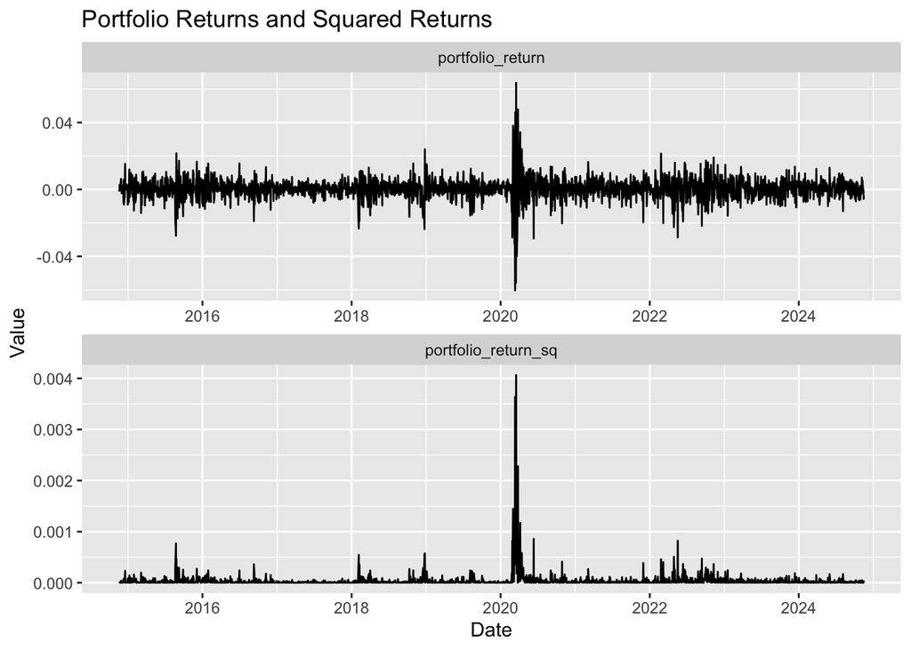

```r
portfolio_returns %>%
  pivot_longer(starts_with("portfolio")) %>%
  ggplot(aes(date, value)) +
  geom_line() +
  facet_wrap(~name, scales = "free", nrow = 2) +
  labs(
    title = "Portfolio Returns and Squared Returns",
    x = "Date",
    y = "Value"
  )
```

## Time Series Modeling

### Checking for Autocorrelation

We fit an ARIMA model to the portfolio returns to check for any autoregressive or moving average components.

```r
portfolio_returns %>%
  mutate(time = row_number()) %>%
  as_tsibble(index = time) %>%
  model(arima = fable::ARIMA(portfolio_return)) %>%
  print()
```

```
# A mable: 1 x 1
                   arima
                 <model>
1 <ARIMA(2,0,2) w/ mean>
```

## GARCH Model Specification and Fitting

### Specifying the GARCH Model

We specify a Threshold GARCH (TGARCH) model to capture the asymmetric effects in volatility.

```r
spec <-
  ugarchspec(
    variance.model = list(
      model = "fGARCH",
      submodel = "TGARCH",
      garchOrder = c(1, 1)
    ),
    mean.model = list(
      armaOrder = c(2, 2),
      include.mean = TRUE
    ),
    distribution.model = "std"  # Student's t-distribution
  )
```

- **Variance Model**: TGARCH(1,1) to capture asymmetry in volatility.
- **Mean Model**: ARMA(2,2) to model the returns.
- **Distribution**: Student’s t-distribution to account for fat tails.

### Fitting the GARCH Model

We fit the specified GARCH model to the portfolio returns.

```r
portfolio_fit <-
  ugarchfit(
    spec = spec,
    data = portfolio_returns$portfolio_return
  )
```

## Model Evaluation

### Comparing Actual vs. Fitted Returns

We compare the actual portfolio returns to the fitted values from the GARCH model.

```r
comparison_data <-
  tibble(
    date = portfolio_returns$date,
    return_actual = portfolio_returns$portfolio_return,
    return_fitted = fitted(portfolio_fit) %>% as.numeric()
  )
```

#### Plotting the Comparison

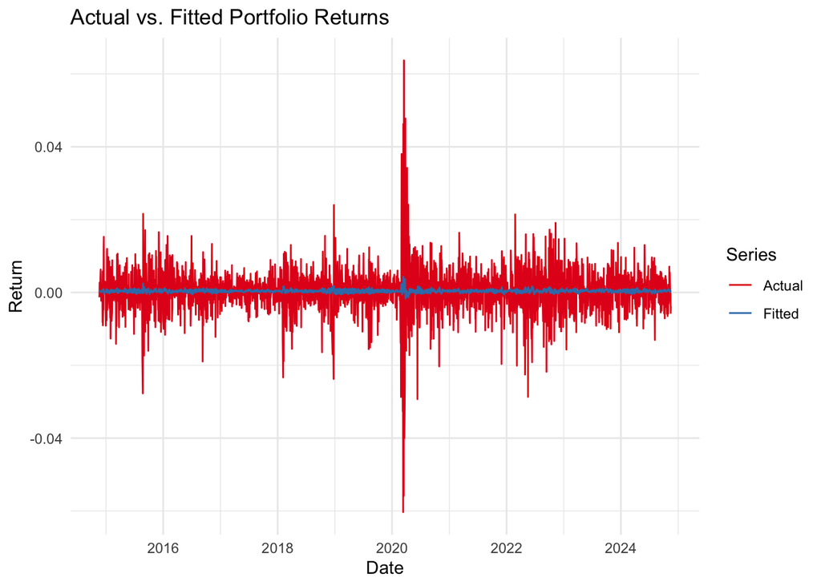

```r
comparison_data %>%
  pivot_longer(-date) %>%
  ggplot(aes(x = date, y = value, color = name)) +
  geom_line() +
  theme_minimal() +
  labs(
    title = "Actual vs. Fitted Portfolio Returns",
    y = "Return",
    x = "Date",
    color = "Series"
  ) +
  scale_color_brewer(
    labels = c("Actual", "Fitted"),
    palette = "Set1"
  )
```

### Analyzing Volatility Estimates

We analyze the estimated volatility from the GARCH model and compare it to the absolute returns.

```r
volatility_data <-
  tibble(
    date = portfolio_returns$date,
    return_abs = abs(portfolio_returns$portfolio_return),
    sigma = sigma(portfolio_fit) %>% as.numeric()
  )
```

#### Plotting Volatility Estimates

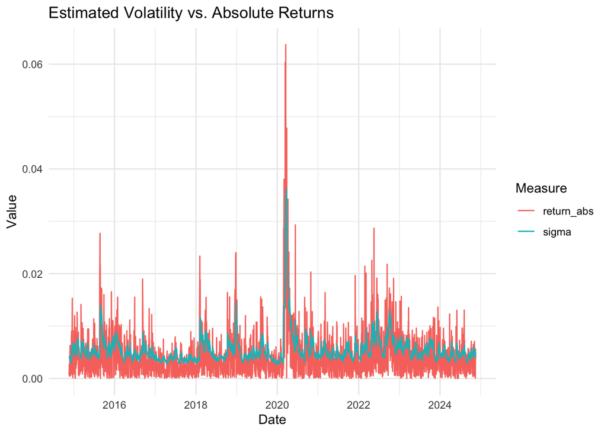

```r
volatility_data %>%
  pivot_longer(
    cols = c(return_abs, sigma),
    names_to = "measure",
    values_to = "value"
  ) %>%
  ggplot(aes(x = date, y = value, color = measure)) +
  geom_line() +
  labs(
    title = "Estimated Volatility vs. Absolute Returns",
    y = "Value",
    x = "Date",
    color = "Measure"
  ) +
  theme_minimal()
```

## Rolling Forecast and VaR Analysis

### Preparing Data for Rolling Forecast

We convert the portfolio returns data into an `xts` object required for the rolling forecast function.

```r
df_portfolio_xts <- xts(
  x = portfolio_returns$portfolio_return,
  order.by = portfolio_returns$date
)
```

### Performing Rolling Forecast with `ugarchroll`

We perform a rolling forecast to evaluate the model’s out-of-sample performance and calculate Value at Risk (VaR).

```r
roll_model <-
  ugarchroll(
    spec = spec,
    data = df_portfolio_xts,
    n.ahead = 1,
    forecast.length = 252, # Approximately one trading year
    refit.every = 50,
    refit.window = "moving",
    calculate.VaR = TRUE,
    VaR.alpha = c(0.01, 0.05)
  )
roll_model
```

```
*-------------------------------------*
*              GARCH Roll             *
*-------------------------------------*
No.Refits       : 6
Refit Horizon   : 50
No.Forecasts    : 252
GARCH Model     : fGARCH(1,1)

fGARCH SubModel : TGARCH
Distribution    : std

Forecast Density:
               Mu  Sigma Skew  Shape Shape(GIG) Realized
2023-11-16 -1e-04 0.0041    0 7.6336          0   0.0000
2023-11-17  3e-04 0.0038    0 7.6336          0   0.0001
2023-11-20  2e-04 0.0035    0 7.6336          0   0.0006
2023-11-21  4e-04 0.0033    0 7.6336          0   0.0023
2023-11-22  2e-04 0.0032    0 7.6336          0   0.0043
2023-11-24  2e-04 0.0032    0 7.6336          0   0.0026

..........................
              Mu  Sigma Skew  Shape Shape(GIG) Realized
2024-11-08 7e-04 0.0047    0 7.3380          0   0.0055
2024-11-11 0e+00 0.0046    0 7.3380          0   0.0001
2024-11-12 6e-04 0.0042    0 7.3380          0  -0.0021
2024-11-13 3e-04 0.0044    0 7.3380          0  -0.0002
2024-11-14 6e-04 0.0040    0 7.7394          0  -0.0056
2024-11-15 2e-04 0.0048    0 7.7394          0  -0.0038

Elapsed: 12.67342 secs
```

- **n.ahead**: Forecast horizon (1 day ahead).
- **forecast.length**: Number of periods to forecast (252 trading days).
- **refit.every**: Refit the model every 50 observations.
- **refit.window**: Use a moving window for refitting.
- **VaR.alpha**: Confidence levels for VaR calculation (1% and 5%).

### Reporting VaR Results

We generate a report of the VaR backtesting results at the 1% significance level.

```r
report(
  roll_model,
  type = "VaR",
  VaR.alpha = 0.01,
  conf.level = 0.95
)
```

```
VaR Backtest Report
===========================================
Model:              fGARCH-std
Backtest Length:    252
Data:

==========================================
alpha:              1%
Expected Exceed:    2.5
Actual VaR Exceed:  2
Actual %:           0.8%

Unconditional Coverage (Kupiec)
Null-Hypothesis:    Correct Exceedances
LR.uc Statistic:    0.117
LR.uc Critical:     3.841
LR.uc p-value:      0.733
Reject Null:        NO

Conditional Coverage (Christoffersen)
Null-Hypothesis:    Correct Exceedances and
                    Independence of Failures
LR.cc Statistic:    0.149
LR.cc Critical:     5.991
LR.cc p-value:      0.928
Reject Null:        NO
```

### Evaluating Forecast Performance

We report the forecast performance measures (FPM) to assess the accuracy of the model’s forecasts.

```r
report(roll_model, type = "fpm")
```

```
GARCH Roll Mean Forecast Performance Measures
---------------------------------------------
Model       : fGARCH
SubModel : TGARCH
No.Refits   : 6
No.Forecasts: 252

        Stats
MSE 0.0000181
MAE 0.0032990
DAC 0.5595000
```

## Visualizing Rolling Forecast Results

We plot various diagnostics from the rolling forecast to assess the model’s performance.

### Conditional Density Forecasts

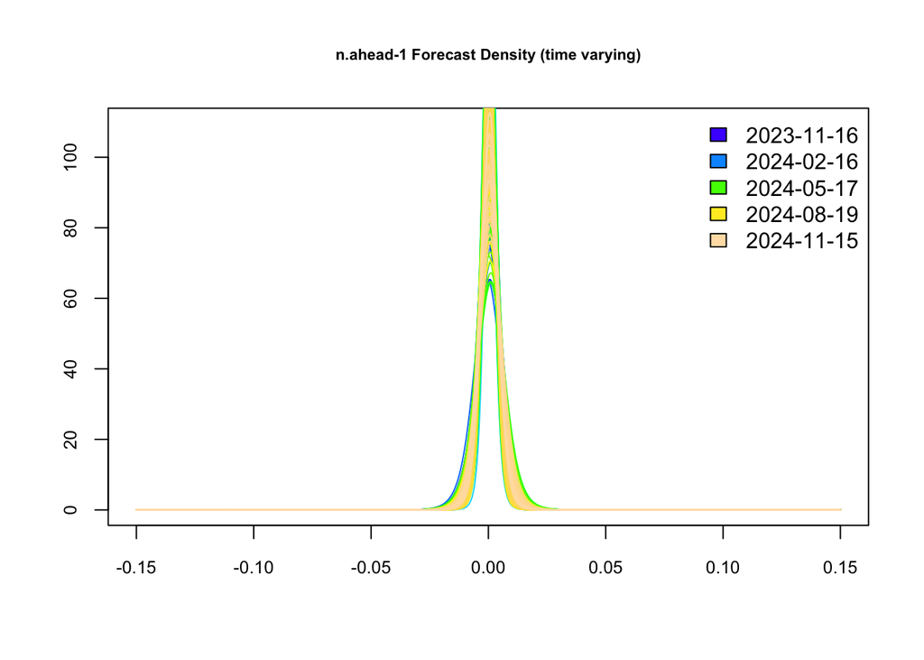

```r
par(mfrow = c(1, 1))
par(new = FALSE) # Reset plotting parameters
plot(roll_model, which = 1)
```

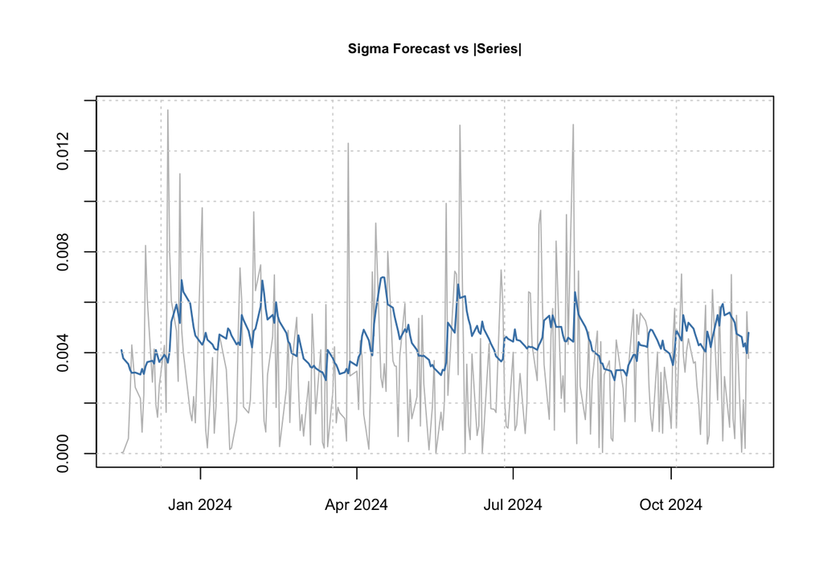

```r
par(mfrow = c(1, 1))
par(new = FALSE)
plot(roll_model, which = 2)
```

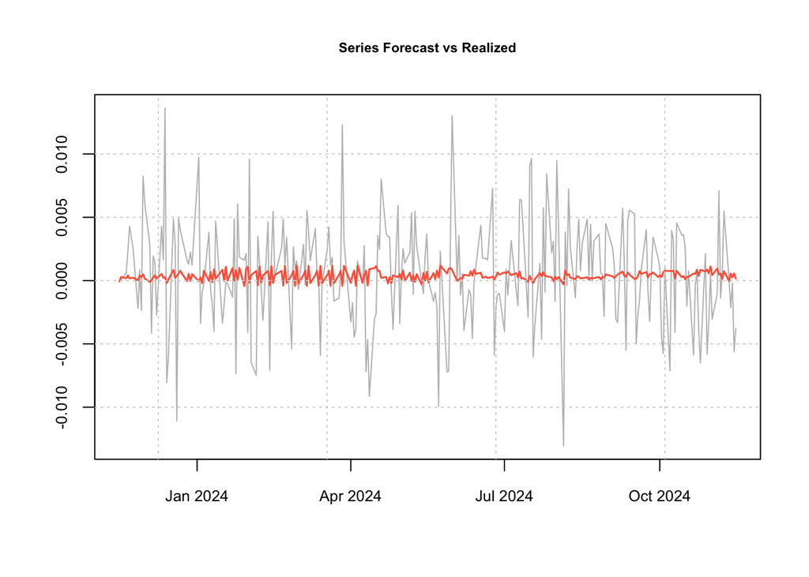

```r
par(mfrow = c(1, 1))
par(new = FALSE)
plot(roll_model, which = 3)
```

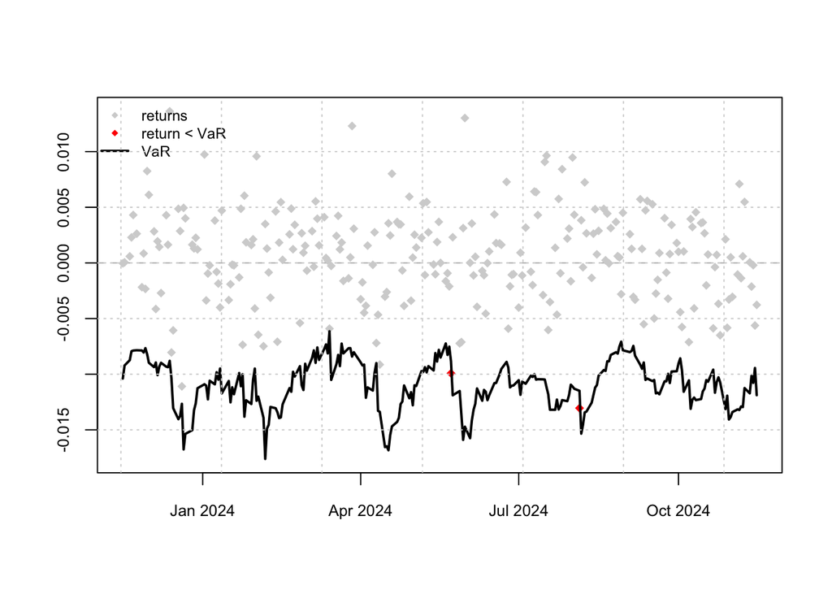

```r
par(mfrow = c(1, 1))
par(new = FALSE)
plot(roll_model, which = 4)
```

## Conclusion

In this session, we:

- Downloaded and prepared S&P 500 stock data.
- Constructed a minimum variance portfolio using portfolio optimization techniques.
- Fitted a TGARCH model to the portfolio returns to model volatility.
- Evaluated the model’s fit and compared actual vs. fitted returns.
- Performed a rolling forecast to assess the model’s out-of-sample performance.
- Calculated and analyzed Value at Risk (VaR) for risk assessment.

This practical application demonstrates the integration of portfolio optimization and time series econometric modeling for financial analysis and risk management.